# Introduction to Python Project : FoodHub Data Analysis

### Problem statement

#### Background

The number of restaurants in New York is increasing day by day. Lots of students and busy professionals rely on those restaurants due to their hectic lifestyles. Online food delivery service is a great option for them. It provides them with good food from their favorite restaurants. A food aggregator company FoodHub offers access to multiple restaurants through a single smartphone app.

The app allows restaurants to receive a direct online order from a customer. The app assigns a delivery person from the company to pick up the order after it is confirmed by the restaurant. The delivery person then uses the map to reach the restaurant and waits for the food package. Once the food package is handed over to the delivery person, he/she confirms the pick-up in the app and travels to the customer's location to deliver the food. The delivery person confirms the drop-off in the app after delivering the food package to the customer. The customer can rate the order in the app. The food aggregator earns money by collecting a fixed margin on the delivery order from the restaurants.

### Objective

The food aggregator company has stored the data of the different orders made by the registered customers in their online portal. They want to analyze the data to get a fair idea about the demand of different restaurants which will help them in enhancing their customer experience.

### Data Dictionary

The data includes various information related to a food order. A detailed data dictionary is provided below.

- **order_id**: Unique ID of the order
- **customer_id**: ID of the customer who ordered the food
- **restaurant_name**: Name of the restaurant
- **cuisine_type**: Cuisine ordered by the customer
- **cost_of_the_order**: Cost of the order
- **day_of_the_week**: Indicates whether the order is placed on a weekday or weekend (The weekday is from Monday to Friday and the weekend is Saturday and Sunday)
- **rating**: Rating given by the customer out of 5
- **food_preparation_time**: Time (in minutes) taken by the restaurant to prepare the food. This is calculated by taking the difference between the timestamps of the restaurant's order confirmation and the delivery person's pick-up confirmation.
- **delivery_time**: Time (in minutes) taken by the delivery person to deliver the food package. This is calculated by taking the difference between the timestamps of the delivery person's pick-up confirmation and drop-off information

### Let us start by importing the required libraries

**Note** : Data loaded from google colab files and not from google drive

```python
import numpy as np
import pandas as pd
pd.set_option('max_colwidth', None)

import matplotlib.pyplot as plt
import seaborn as sns
```

### Understanding the structure of the data

```python
# uncomment and run the following lines for Google Colab
# from google.colab import drive
# drive.mount('/content/drive')
orders = pd.read_csv('/content/sample_data/foodhub_order.csv')
```

```python
# Write your code here to read the data
data = orders.copy()
```

```python
# Write your code here to view the first 5 rows
data.head()
```

|  | order_id | customer_id | restaurant_name | cuisine_type | cost_of_the_order | day_of_the_week | rating | food_preparation_time | delivery_time |
| --- | --- | --- | --- | --- | --- | --- | --- | --- | --- |
| 0 | 1477147 | 337525 | Hangawi | Korean | 30.75 | Weekend | Not given | 25 | 20 |
| 1 | 1477685 | 358141 | Blue Ribbon Sushi Izakaya | Japanese | 12.08 | Weekend | Not given | 25 | 23 |
| 2 | 1477070 | 66393 | Cafe Habana | Mexican | 12.23 | Weekday | 5 | 23 | 28 |
| 3 | 1477334 | 106968 | Blue Ribbon Fried Chicken | American | 29.20 | Weekend | 3 | 25 | 15 |
| 4 | 1478249 | 76942 | Dirty Bird to Go | American | 11.59 | Weekday | 4 | 25 | 24 |

### **Question 1:** How many rows and columns are present in the data? [0.5 mark]

```python
# Write your code here
data.shape
```

```
(1898, 9)
```

#### Observations:

Dataset has

- **1898** Rows
- **9** Columns

### **Question 2:** What are the datatypes of the different columns in the dataset? (The info() function can be used) [0.5 mark]

```python
# Write your code here
data.info()
```

```
<class 'pandas.core.frame.DataFrame'>
RangeIndex: 1898 entries, 0 to 1897
Data columns (total 9 columns):
 #   Column                 Non-Null Count  Dtype
---  ------                 --------------  -----
 0   order_id               1898 non-null   int64
 1   customer_id            1898 non-null   int64
 2   restaurant_name        1898 non-null   object
 3   cuisine_type           1898 non-null   object
 4   cost_of_the_order      1898 non-null   float64
 5   day_of_the_week        1898 non-null   object
 6   rating                 1898 non-null   object
 7   food_preparation_time  1898 non-null   int64
 8   delivery_time          1898 non-null   int64
dtypes: float64(1), int64(4), object(4)
memory usage: 133.6+ KB
```

#### Observations:

- Total 9 columns are present
- There are 5 numerical columns : `order_id`, `customer_id`, `cost_of_the_order`, `food_preparation_time`
  - Among these `cost_of_the_order` is declared as `float64`
  - Rest 4 columns are `int64`
- There are 4 object columns : `restaurant_name`, `cuisine_type`, `day_of_the_week`, `rating`
- Rating column
  - `rating` column captures numerical value and should have been a integer type but is declared as object
  - Non rated values are present in this column but are captured as this text `Not given`
- Nulls
  - All columns are marked as `non-null` and hence should not be nulls in any of the column.

### **Question 3:** Are there any missing values in the data? If yes, treat them using an appropriate method. [1 mark]

```python
# Write your code here

print("\nMissing values per column:\n", data.isnull().sum())
print("-"*10)
print('\nRating count by rating value\n', data['rating'].value_counts())
```

```
Missing values per column:
 order_id                 0
customer_id              0
restaurant_name          0
cuisine_type             0
cost_of_the_order        0
day_of_the_week          0
rating                   0
food_preparation_time    0
delivery_time            0
dtype: int64
----------

Rating count by rating value
 rating
Not given    736
5            588
4            386
3            188
Name: count, dtype: int64
```

#### Observations:

- **Non Nulls**
  - All columns are marked as `non-null` and hence there are no null values in any of the column.
- **Rating column**
  - Non rated values are present in `rating` column.
  - They are captured `Not given`

##### **Missing data treatment**

- `rating` column is converted to `int64` from `object`
- The 'Not given`string value is replaced with`NaN`. Conversion is done first to float and then to int64 to preserve the NaN
- Conversion is stored back in the same `rating` column
- Following code converts and verifies

```python
data['rating'] = data['rating'].replace('Not given', np.nan)
data['rating'] = data['rating'].astype(float).astype('Int64')

print("\n Data Info\n", data.info())
print("-"*10)
print('\nRating count by rating value\n', data['rating'].value_counts(dropna=False))
```

```
<class 'pandas.core.frame.DataFrame'>
RangeIndex: 1898 entries, 0 to 1897
Data columns (total 9 columns):
 #   Column                 Non-Null Count  Dtype
---  ------                 --------------  -----
 0   order_id               1898 non-null   int64
 1   customer_id            1898 non-null   int64
 2   restaurant_name        1898 non-null   object
 3   cuisine_type           1898 non-null   object
 4   cost_of_the_order      1898 non-null   float64
 5   day_of_the_week        1898 non-null   object
 6   rating                 1162 non-null   Int64
 7   food_preparation_time  1898 non-null   int64
 8   delivery_time          1898 non-null   int64
dtypes: Int64(1), float64(1), int64(4), object(3)
memory usage: 135.4+ KB

 Data Info
 None
----------

Rating count by rating value
 rating
<NA>    736
5       588
4       386
3       188
Name: count, dtype: Int64
```

##### **Imputing Rating data - considerations & next steps**

- Since the rating column is categorical and also ordinal, filling the missing values with median is an option
- If the mean of the rating is close the median, imputing with mean is also an option
- We can also study the correlation of ratings with other columns cost, preparation time and delivery time
- Also a high percentage (38.7%) data has no rating

```python
print("\nMean (Rating) : ", data['rating'].mean())
print("Median (Rating) : ", data['rating'].median())
print("Mode (Rating) : ", data['rating'].mode())

correlation = data[['delivery_time', 'food_preparation_time','rating', 'cost_of_the_order']].corr()
correlation
```

```
Mean (Rating) :  4.344234079173838
Median (Rating) :  5.0
Mode (Rating) :  0    5
Name: rating, dtype: Int64
```

|  | delivery_time | food_preparation_time | rating | cost_of_the_order |
| --- | --- | --- | --- | --- |
| delivery_time | 1.000000 | 0.011094 | -0.009804 | -0.029949 |
| food_preparation_time | 0.011094 | 1.000000 | -0.006083 | 0.041527 |
| rating | -0.009804 | -0.006083 | 1.000000 | 0.033983 |
| cost_of_the_order | -0.029949 | 0.041527 | 0.033983 | 1.000000 |

**Observations and Imputing next steps:**

- No ratings for 1 and 2 shows people rarely have given low ratings.
- Data is highly skewed towards 5 and 4 i.e., Median is 5 and Mean is 4.34
- Filling with Mean (4.34) is not a good choice as ratings are discrete (1,2,3, 4,5) and also the distribution is not normal
- There is nearly no correlation to cost, delivery time or preparation time.

Hence, it is decided to use the simple approach of imputing with 5 in a new column 'new_rating'.

```python
data['new_rating'] = data['rating'].copy()
data['new_rating'] = data['new_rating'].fillna(5)
print(data[['rating', 'new_rating']].head())
```

```
   rating  new_rating
0    <NA>           5
1    <NA>           5
2       5           5
3       3           3
4       4           4
```

### **Question 4:** Check the statistical summary of the data. What is the minimum, average, and maximum time it takes for food to be prepared once an order is placed? [2 marks]

```python
# Write your code here
data.describe().T
```

|  | count | mean | std | min | 25% | 50% | 75% | max |
| --- | --- | --- | --- | --- | --- | --- | --- | --- |
| order_id | 1898.0 | 1477495.5 | 548.049724 | 1476547.0 | 1477021.25 | 1477495.5 | 1477969.75 | 1478444.0 |
| customer_id | 1898.0 | 171168.478398 | 113698.139743 | 1311.0 | 77787.75 | 128600.0 | 270525.0 | 405334.0 |
| cost_of_the_order | 1898.0 | 16.498851 | 7.483812 | 4.47 | 12.08 | 14.14 | 22.2975 | 35.41 |
| rating | 1162.0 | 4.344234 | 0.741478 | 3.0 | 4.0 | 5.0 | 5.0 | 5.0 |
| food_preparation_time | 1898.0 | 27.37197 | 4.632481 | 20.0 | 23.0 | 27.0 | 31.0 | 35.0 |
| delivery_time | 1898.0 | 24.161749 | 4.972637 | 15.0 | 20.0 | 25.0 | 28.0 | 33.0 |
| new_rating | 1898.0 | 4.598525 | 0.662289 | 3.0 | 4.0 | 5.0 | 5.0 | 5.0 |

#### Observations:

Following are the food preparation times taken for

1. Minimum = 20 Mins
2. Average = 27.37 Mins
3. Maximum = 35.0 Mins

### **Question 5:** How many orders are not rated? [1 mark]

```python
# Write the code here
print('\nRating count by rating value\n', data['rating'].value_counts(dropna=False))

print('\nRating count by rating value after Imputing \n', data['new_rating'].value_counts(dropna=False))
```

```
Rating count by rating value
 rating
<NA>    736
5       588
4       386
3       188
Name: count, dtype: Int64

Rating count by rating value after Imputing
 new_rating
5    1324
4     386
3     188
Name: count, dtype: Int64
```

#### Observations:

- 736 Orders have no ratings as per `rating` column
- **Note** : These NA values are imputed in `new_rating` column

### Exploratory Data Analysis (EDA)

### **Question 6:** Explore all the variables and provide observations on their distributions. (Generally, histograms, boxplots, countplots, etc. are used for univariate exploration.) [9 marks]

**Exploring the numerical variables in following order**

1. cost_of_the_order
2. food_preparation_time
3. delivery_time
4. rating
5. customer_id

**Exploring the non-numerical variables in following order**

1. restaurant_name
2. cuisine_type
3. day_of_the_week

#### [Univariate 1] Observations on Cost of the order

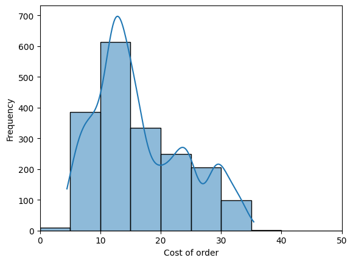

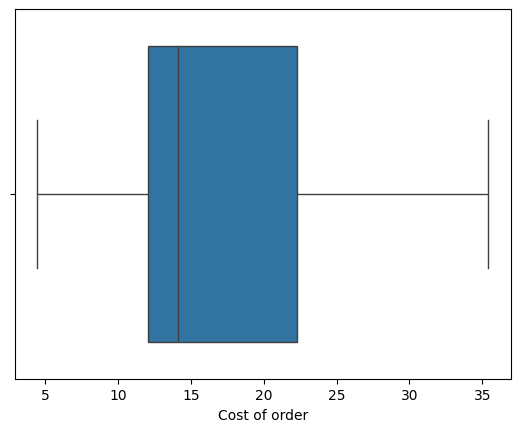

```python
# Write the code here
bins = [i for i in range(0, 55, 5)]
plt.xlim(0,50)
sns.histplot(data=data, x = 'cost_of_the_order', kde=True, bins = bins)
plt.xlabel('Cost of order')
plt.ylabel('Frequency')
plt.show()

sns.boxplot(data=data, x = 'cost_of_the_order')
plt.xlabel('Cost of order')
plt.show()
```

- Distribution of cost is slightlyt skewed to the right
- There are no outliers on either side (observed from the boxplot)
- Cost range `$`10 to `$`15 has the highest number of orders
- 50% of the orders fall in the `$10` to `$20` range
- Order count has decreased as the cost went high (This correlation can be analysed more in Multivariate)
- Presence of multiple groups of cost ranges are visiblein the kde

#### [Univariate 2] Observations on Food preparation time

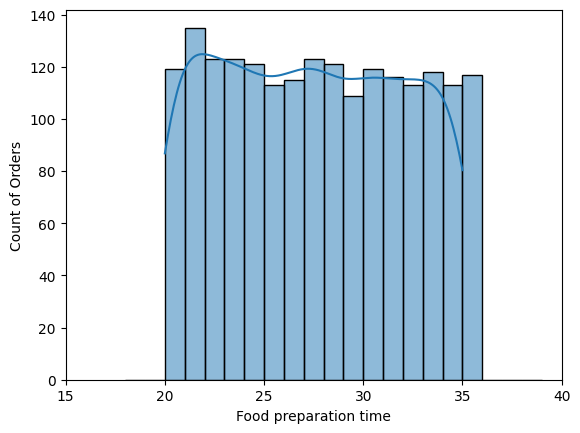

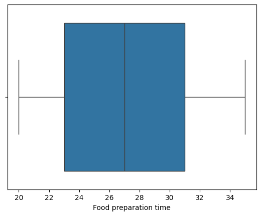

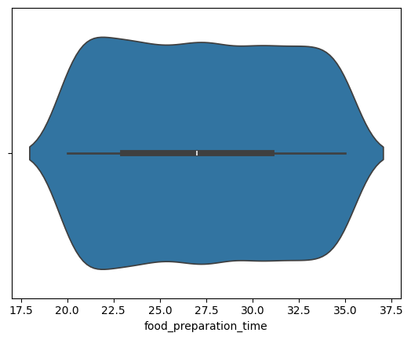

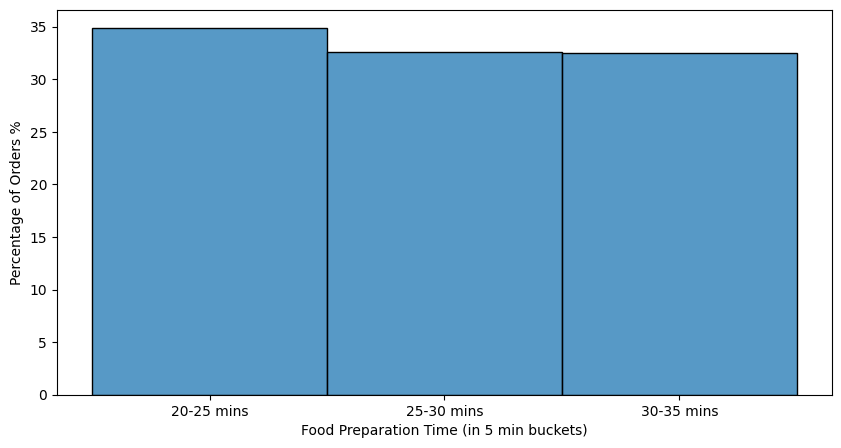

```python
# Write the code here

## basic histogram with KDE
bins = [i for i in range(18, 40, 1)]
xlabel = 'Food preparation time'
plt.xlim(15,40)
plt.xlabel(xlabel)
plt.ylabel('Count of Orders')
sns.histplot(data=data, x = 'food_preparation_time', kde=True, bins = bins)
plt.show()

## Box plot
sns.boxplot(data=data, x = 'food_preparation_time')
plt.xlabel(xlabel)
plt.show()

## violin plot
sns.violinplot(x=data['food_preparation_time'])
plt.show()

## advanced histogram with bins in the range of 15-20, 20-25, 25-30, 30-35 Mins
bins = list(range(15, 40, 5))
labels = [f"{bins[i]}-{bins[i+1]} mins" for i in range(len(bins)-1)]

data['prep_time_bins'] = pd.cut(data['food_preparation_time'], bins=bins,
                                labels=labels, right=False)

plt.figure(figsize=(10, 5))
sns.histplot(data=data, x='prep_time_bins', stat="percent", discrete=True)

plt.xlabel("Food Preparation Time (in 5 min buckets)")
plt.ylabel("Percentage of Orders %")
plt.show()
```

3 charts are generated for the food preparation time data

1. Histogram (basic and advanced with 5 min buckets)
2. Boxplot
3. Violin plot

**Observations**

- Distribution of food preparation time is uniform. This is evident from the histograms and other charts
- There are no outliers on either side (observed from the boxplot)
- Every min (in the 20 to 35 min range) food is prepared for 100 or more orders

#### [Univariate 3] Observations on Delivery time

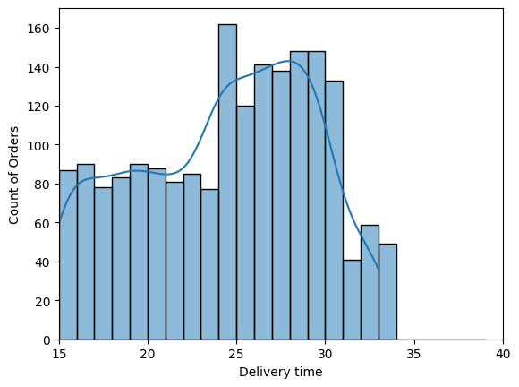

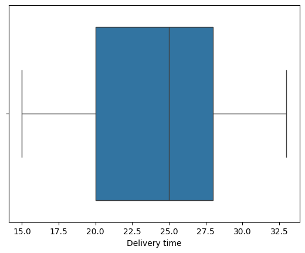

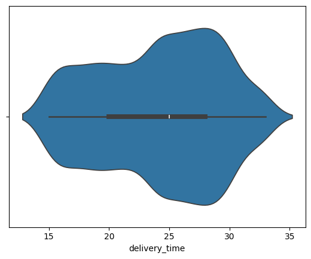

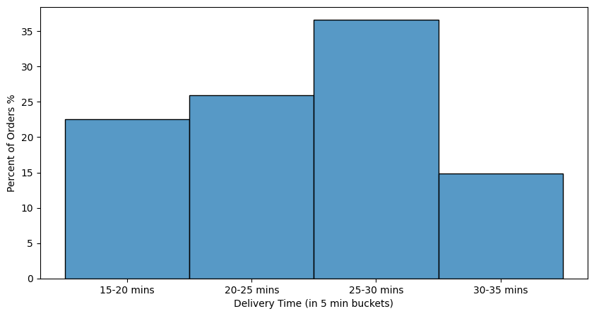

[output not shown]

```python
# Write the code here

## basic histogram with KDE
bins = [i for i in range(12, 40, 1)]
xlabel = 'Delivery time'
plt.xlim(15,40)
plt.xlabel(xlabel)
plt.ylabel('Count of Orders')
sns.histplot(data=data, x = 'delivery_time', kde=True, bins = bins)
plt.show()

## Box plot
sns.boxplot(data=data, x = 'delivery_time')
plt.xlabel(xlabel)
plt.show()

## violin plot
sns.violinplot(x=data['delivery_time'])
plt.show()

## advanced histogram with bins in the range of 15-20, 20-25, 25-30, 30-35 Mins
bins = list(range(15, 40, 5))
labels = [f"{bins[i]}-{bins[i+1]} mins" for i in range(len(bins)-1)]

data['delivery_time_bins'] = pd.cut(data['delivery_time'], bins=bins,
                                labels=labels, right=False)

plt.figure(figsize=(10, 5))
sns.histplot(data=data, x='delivery_time_bins', stat="percent", discrete=True)

plt.xlabel("Delivery Time (in 5 min buckets)")
plt.ylabel("Percent of Orders %")
plt.show()

# Write the code here
order_cost_gt_20 = (data['delivery_time'] > 30).sum()
order_percent = (order_cost_gt_20/len(data)) * 100
print(f"Percentage of orders costing more than $20: {order_percent:.2f}%")
```

3 charts are generated for the delivery time data

1. Histogram (basic and advanced with 5 min buckets)
2. Boxplot
3. Violin plot

**Observations**

- Distribution of delivery time is left skewed
- There are no outliers plotted on either side of the boxplot
- Nearly 50% of the orders are delivered in 25 Mins
- Highest percent of orders are delivered in the 25 - 30 Min range, when a 5min window is taken

#### [Univariate 4] Observations on Rating

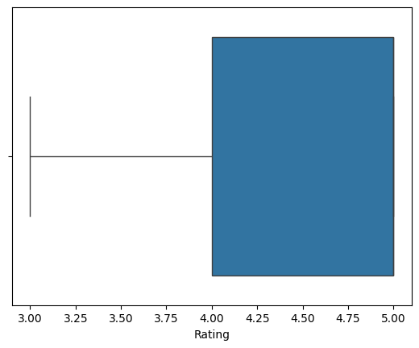

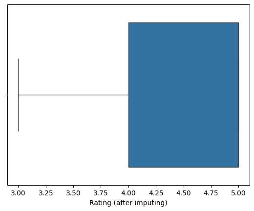

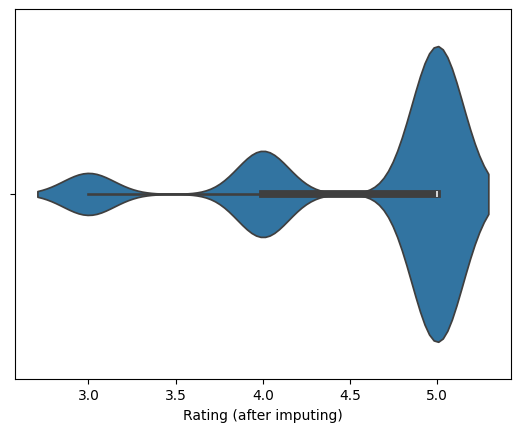

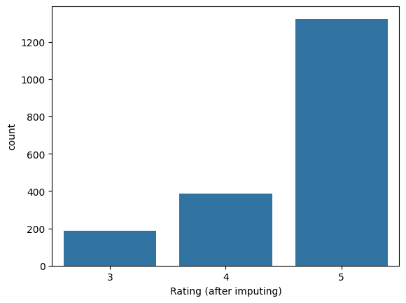

```python
# Write the code here

## boxplot
sns.boxplot(x = data['new_rating'])
plt.xlabel('Rating')
plt.show()

sns.boxplot(x = data['rating'])
plt.xlabel('Rating (after imputing)')
plt.show()

## violin plot
sns.violinplot(x=data['new_rating'])
plt.xlabel('Rating (after imputing)')
plt.show()

## Bar graph
sns.countplot(data=data, x='new_rating');
plt.xlabel('Rating (after imputing)')
plt.show()
```

**Observations:**

- Rating is left skewed. This is verified with provided data and imputed data. i.e., High number of Orders are rated '5'
- No orders are rated below 3 (i.e., no rating for 1 and 2). This could be an issue in the data capturing aspect also

#### [Univariate 5] Observations on Customer

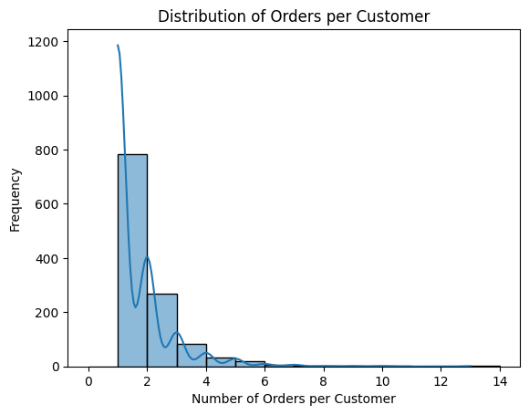

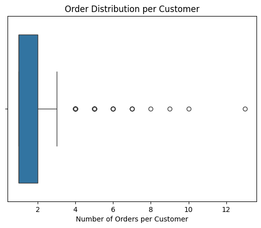

```
Number of unique customers: 1200

Top 10 customers
customer_id
52832     13
47440     10
83287      9
250494     8
259341     7
65009      7
276192     7
82041      7
115213     6
60052      6
Name: count, dtype: int64

Total orders from top 10 customers 80
```

```python
# Histogram of Customers and count of Orders placed
order_counts = data['customer_id'].value_counts()
bins = [i for i in range(0, 15, 1)]
sns.histplot(order_counts, bins=bins, kde=True)
plt.xlabel("Number of Orders per Customer")
plt.ylabel("Frequency")
plt.title("Distribution of Orders per Customer")
plt.show()

print("-" * 10)

# Boxplot of Customers and count of Orders placed
sns.boxplot(x=order_counts)
plt.xlabel("Number of Orders per Customer")
plt.title("Order Distribution per Customer")
plt.show()

# Unique customer count
num_unique_customers = data['customer_id'].nunique()
print("\nNumber of unique customers:", num_unique_customers)

# top 10 customers
print("\nTop 10 customers")
top_customers = order_counts.head(10)
print(top_customers)
print("\nTotal orders from top 10 customers", top_customers.sum())
```

#### [Univariate 6] Observations on Restaurant

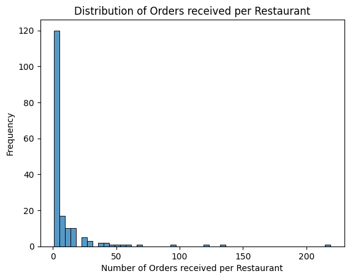

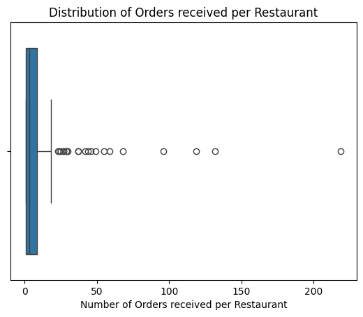

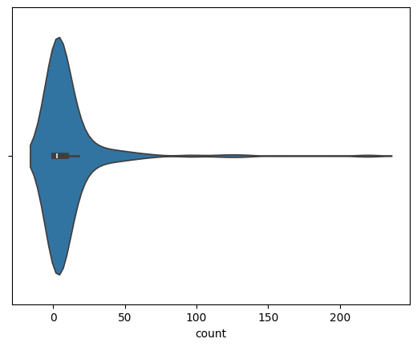

```
Number of unique restaurants: 178
----------
restaurant_name
Shake Shack                      219
The Meatball Shop                132
Blue Ribbon Sushi                119
Blue Ribbon Fried Chicken         96
Parm                              68
RedFarm Broadway                  59
RedFarm Hudson                    55
TAO                               49
Han Dynasty                       46
Blue Ribbon Sushi Bar & Grill     44
Name: count, dtype: int64
----------

Total orders received by top 10 restaurants  887
----------

Distribution of Order count received by Restaurants
```

|  | count |
| --- | --- |
| count | 178.000000 |
| mean | 10.662921 |
| std | 24.047008 |
| min | 1.000000 |
| 25% | 1.000000 |
| 50% | 3.000000 |
| 75% | 8.750000 |
| max | 219.000000 |

**dtype:** float64

```python
# Histogram of Restaurants and Orders received
order_counts = data['restaurant_name'].value_counts()
sns.histplot(order_counts, bins=50)
plt.xlabel("Number of Orders received per Restaurant")
plt.ylabel("Frequency")
plt.title("Distribution of Orders received per Restaurant")
plt.show()

print("-" * 10)

# Boxplot of Restaurants and Orders received
sns.boxplot(x=order_counts)
plt.xlabel("Number of Orders received per Restaurant")
plt.title("Distribution of Orders received per Restaurant")
plt.show()
print("-" * 10)

# Violin plot of Restaurants and Orders received
sns.violinplot(x=order_counts)
plt.show()

# Unique restaurant count
num_unique_restaurants = data['restaurant_name'].nunique()
print("\nNumber of unique restaurants:", num_unique_restaurants)
print("-" * 10)

# top 10 restaurants
top_restaurants = order_counts.head(10)
print(top_restaurants)
print("-" * 10)
print("\nTotal orders received by top 10 restaurants ", top_restaurants.sum())
print("-" * 10)

print('\nDistribution of Order count received by Restaurants')
order_counts.describe().T
```

**Observations**